# Assignment 10

## Try to submit as an HTML file

Print your name below

```python
print("June Yun")
```

```
June Yun
```

Import the "pandas" and "matplotlib.pyplot" libraries.

```python
# Write your answer here:
import pandas as pd
import matplotlib.pyplot as plt
```

In this assignment, we will work with a World Bank  
dataset on the proportion of urban population across  
countries, from 2016-2020.

- This is an example of a "panel"/"longitudinal" dataset

which contains information about the same unit (country)  
over time.

- This is in "long" format (see Lecture 22)

(a) Import data and parse dates

- Import "data_raw/wdi_long.csv"
- Create a new column called "date" which uses `pd.to_datetime(...,format = ...)`

to convert year to a date format

- To get full points use wild cards to establish the format.

Hint: See Lecture 21 for information about wild cards

```python
# Write your own code
#import "data_raw/wdi_long.csv"
wdi_long = pd.read_csv("data_raw/wdi_long.csv")
# create a new column called "date" which uses pd.to_datetime(...,format = ...) to convert year to a date format
wdi_long["date"] = pd.to_datetime(wdi_long["year"], format = "%Y")
```

(b) Sort by two columns

- Create a new dataset "data_sorted" that sorts by "country_name" and "date"

HINT: Include a list of column names as the main sorting argument.

```python
# Write your own code
data_sorted = wdi_long.sort_values(by=["country_name", "date"])
```

(c) Compute grouped time differences

**Example**

- Each country has data for multiple dates
- The following code calculates the time-difference between each date

```
(data_sorted.groupby("country_name")["date"]
            .diff())
```

**Instructions**:

- Now, instead of ["date"] use `["prop_urban"]`
- Store the result in a new column called "diff_prop_urban"
- This adds a new column with the country-level changes in

the urban propulaton each year

HINT: Check Lecture 22 for using `.diff()`  
Note: Using ".groupby()" is important so that each country is analyzed  
separately.

```python
# Write your own code
wdi_long["diff_prop_urban"] = wdi_long.groupby("country_name")["prop_urban"].diff()
```

(d) Plot time series for single country

- Use ".query()" to subset "data_sorted" for rows that satisfy

$\quad$ `'country_name == "United States"'`

- Produce a line plot with the evolution of "prop_urban" over time in the

United States

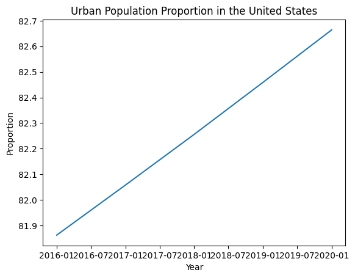

```python
# Write your own code
data_sorted = wdi_long.query('country_name == "United States"')

# Create line plot of prop_urban over time for the United States
plt.plot(data_sorted['date'], data_sorted['prop_urban'])
plt.title('Urban Population Proportion in the United States')
plt.xlabel('Year')
plt.ylabel('Proportion')
plt.show()
```

(e) Convert to wide format

```
   index = 'country_name'
   columns = 'year'
   values =  'prop_urban'
```

- Display the dataset to check that it is in wide format

HINT: See Lecture 22 for details

```python
# Write your own code
data_wide = data_sorted.pivot(index='country_name', columns='year', values='prop_urban')
print(data_wide)
```

```
year             2016    2017    2018    2019    2020
country_name
United States  81.862  82.058  82.256  82.459  82.664
```